# Approximating a correlation matrix

Andrew MacDonald

7 September 2017

## The goal

> Can we accurately recover a simulated correlation matrix, using random effects and/or latent variable models?

In community ecology we often want to model species abundances, usually as a “response” to the environment or some manipulation. But species do not respond to anything alone, but often show correlated responses. These correlations can be encouraged by mutualisms, facilitation and competition etc – even other, unmeasured environmental variables. Or all of these at once! It’s a fun challenge.

Given that these effects exist, any attempt to model community composition should include this non-independence. One way to do this is to estimate correlated effects for each species, based on their abundances in different samples (perhaps after accounting for their different site effects). These models are described in detail in Warton et al. (2015).

$$y = F(\mu_{ij}, \phi)$$

$$g(\mu_{ij}) = \alpha_i + \beta_{0j} + \mathbf x' \mathbf B_j + u_{ij}$$

$$u_{ij} \sim N(\mathbf 0 , \mathbf \Sigma)$$

Warton et al. (Warton et al. 2015) discuss how to approximate a correlation matrix using a simple “latent variable” approach. This approach can work with less data – often we have too many species, and/or too little data from the field, to estimate the correlation matrix directly.

Here I am going to start with a known correlation matrix and then try to recover it based on a few different models.

## Simulating data

First I generate a correlation matrix:

```r
# normal distribution -- its biomass or something!

set.seed(4812)
# species correlation
sppcors <- rethinking::rlkjcorr(1, K = 5, eta = 1.5)

# variance of each species
# sppvars <- runif(5, min = 1, max = 1.5)
# actually not using this; this is a complication that can be added later if I want.

# lognormal abundances
sppmeans <- rlnorm(5, log(17))

## sample the species -- using a constant variace in each species of 0.7
spp_lambdas <- MASS::mvrnorm(n = 10, mu = sppmeans, Sigma = diag(0.7, 5) %*% sppcors %*% diag(0.7, 5))

# reshaping the data: the dataset needs a bit of massaging to be useful later
species_sites <- spp_lambdas %>%
  as.data.frame %>%
  set_names(paste0("sp", LETTERS[1:5])) %>%
  rownames_to_column("site") %>%
  gather(spp, true_mean, -site) %>%
  arrange(site) %>%
  # I are using a multivariate normal distribution to sample "average abundances". Actually sampling abundances from a poisson like normal.  I suppose these will be overdispersed, in fact, because the average that they are based on is itself variable.
  mutate(obs_abd = map_dbl(true_mean, rpois, n = 1)) %>%
  # add index for species
  mutate(spp_id  = rethinking::coerce_index(spp),
         site_id = rethinking::coerce_index(site))

knitr::kable(head(species_sites))
```

| site | spp | true_mean | obs_abd | spp_id | site_id |
| --- | --- | --- | --- | --- | --- |
| 1 | spA | 16.332633 | 21 | 1 | 1 |
| 1 | spB | 8.079800 | 6 | 2 | 1 |
| 1 | spC | 9.928633 | 12 | 3 | 1 |
| 1 | spD | 20.994232 | 24 | 4 | 1 |
| 1 | spE | 13.710633 | 13 | 5 | 1 |
| 10 | spA | 17.537230 | 11 | 1 | 2 |

So now I have poisson counts of species abundances, which are correlated with each other, and sampled a few times.

_ as an aside, I suppose that the means that these poisson counts were based on could also be the response variable we are considering. So we might say that the first represents biomass, the second counts (suppose, e.g. that these are plants and size and fecundity are perfectly related to each other)._

### Visualizing the fake data

Let’s use a simple visualization to see if this works as I suspect. I’m going to visualize the abundance data using NMDS from the vegan package.

```r
sol_spp <- species_sites %>%
  select(site, spp, obs_abd) %>%
  spread(spp, obs_abd) %>%
  remove_rownames %>%
  column_to_rownames("site") %>%
  as.matrix %>%
  decostand("hellinger") %>%
  metaMDS()
```

```
## *** Solution reached
```

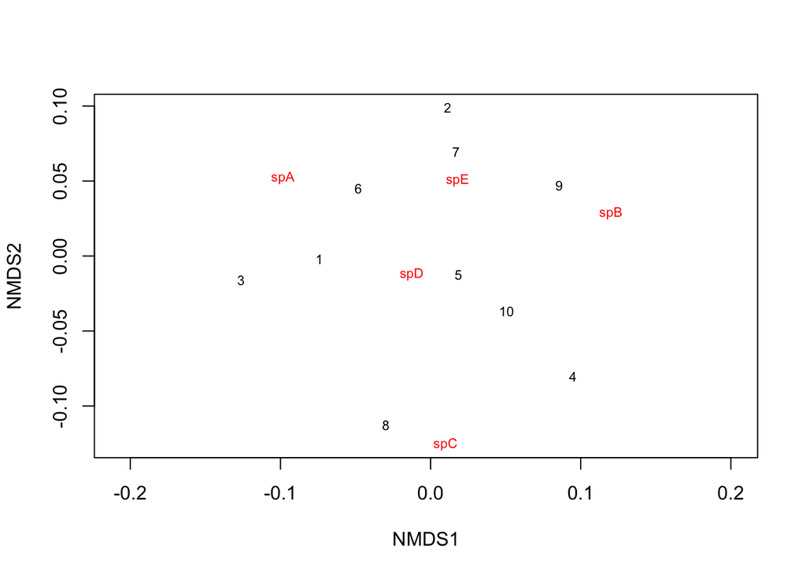

```r
plot(sol_spp, type = "t")
```

This should be consistent with the correlation matrix that started it all:

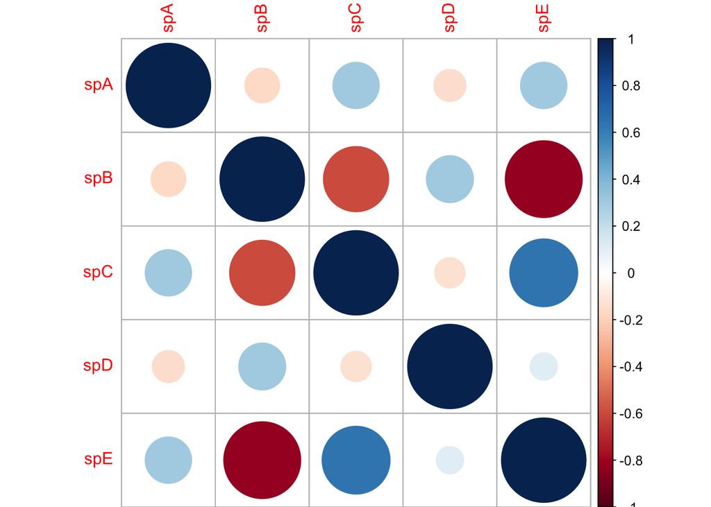

```r
dimnames(sppcors) <- replicate(2, set_names(paste0("sp", LETTERS[1:5])), simplify = FALSE)
corrplot::corrplot(sppcors)
```

## via rstanarm

The most direct means is also the least likely to work. Here is the form of the model wherein the entire covariance matrix is estimated from the data. This uses a simplified version of the model formula proposed in the appendix of Warton et al.

```r
fit_stan_ranspp <- stan_glmer(obs_abd ~ 0 +
                                (1 | spp) +
                                (1 | site) +
                                (0 + spp | site),
                              data=species_sites, family="poisson", chains = 1)
```

```
##
##
## Gradient evaluation took 0.000164 seconds
## 1000 transitions using 10 leapfrog steps per transition would take 1.64 seconds.
## Adjust your expectations accordingly!
##
##
## Iteration:    1 / 2000 [  0%]  (Warmup)
## Iteration:  200 / 2000 [ 10%]  (Warmup)
## Iteration:  400 / 2000 [ 20%]  (Warmup)
## Iteration:  600 / 2000 [ 30%]  (Warmup)
## Iteration:  800 / 2000 [ 40%]  (Warmup)
## Iteration: 1000 / 2000 [ 50%]  (Warmup)
## Iteration: 1001 / 2000 [ 50%]  (Sampling)
## Iteration: 1200 / 2000 [ 60%]  (Sampling)
## Iteration: 1400 / 2000 [ 70%]  (Sampling)
## Iteration: 1600 / 2000 [ 80%]  (Sampling)
## Iteration: 1800 / 2000 [ 90%]  (Sampling)
## Iteration: 2000 / 2000 [100%]  (Sampling)
##
##  Elapsed Time: 14.3737 seconds (Warm-up)
##                8.74461 seconds (Sampling)
##                23.1183 seconds (Total)
```

```r
VarCorr(fit_stan_ranspp)
```

```
##  Groups Name        Std.Dev. Corr
##  site   sppspA      0.16103
##         sppspB      0.15158  -0.082
##         sppspC      0.13294  -0.140  0.108
##         sppspD      0.11560   0.149  0.087  0.071
##         sppspE      0.12355   0.034  0.006 -0.073  0.060
##  site   (Intercept) 0.13302
##  spp    (Intercept) 2.63524
```

```r
sppcors
```

```
##            spA        spB        spC        spD        spE
## spA  1.0000000 -0.1696059  0.3012655 -0.1451415  0.3017900
## spB -0.1696059  1.0000000 -0.5966155  0.3092676 -0.8286784
## spC  0.3012655 -0.5966155  1.0000000 -0.1301203  0.6456207
## spD -0.1451415  0.3092676 -0.1301203  1.0000000  0.1056461
## spE  0.3017900 -0.8286784  0.6456207  0.1056461  1.0000000
```

That.. doesn’t look very good! the correlation values are all very far away from the original numbers!

Maybe it doesn’t all gotta be bayesian? Wardon et al originally went with `lme4`.

```r
library(lme4)
fit.glmm = glmer(obs_abd ~ 0 +
                   (1 | spp) +
                   (1 | site) +
                   (0 + spp | site),
                 data=species_sites, family=poisson(link = "log"))

summary(fit.glmm)
```

```
## Generalized linear mixed model fit by maximum likelihood (Laplace
##   Approximation) [glmerMod]
##  Family: poisson  ( log )
## Formula: obs_abd ~ 0 + (1 | spp) + (1 | site) + (0 + spp | site)
##    Data: species_sites
##
##      AIC      BIC   logLik deviance df.resid
##    348.9    381.4   -157.5    314.9       33
##
## Scaled residuals:
##      Min       1Q   Median       3Q      Max
## -1.42504 -0.51812  0.05103  0.51150  1.29888
##
## Random effects:
##  Groups Name        Variance Std.Dev. Corr
##  site   sppspA      0.08453  0.2907
##         sppspB      0.09182  0.3030   -0.32
##         sppspC      0.04368  0.2090   -0.51  0.43
##         sppspD      0.01843  0.1358    0.59  0.53  0.12
##         sppspE      0.02438  0.1561    0.41  0.29 -0.73  0.38
##  site.1 (Intercept) 0.00000  0.0000
##  spp    (Intercept) 6.84357  2.6160
## Number of obs: 50, groups:  site, 10; spp, 5
```

```r
sppcors
```

```
##            spA        spB        spC        spD        spE
## spA  1.0000000 -0.1696059  0.3012655 -0.1451415  0.3017900
## spB -0.1696059  1.0000000 -0.5966155  0.3092676 -0.8286784
## spC  0.3012655 -0.5966155  1.0000000 -0.1301203  0.6456207
## spD -0.1451415  0.3092676 -0.1301203  1.0000000  0.1056461
## spE  0.3017900 -0.8286784  0.6456207  0.1056461  1.0000000
```

## via boral

Of course, the authors of these papers offer their own means of accomplishing these ends: `boral`, which is an R package

```r
# need to make a species x site matrix firxt

species_sites_forboral <- species_sites %>%
  select(spp, site, obs_abd) %>%
  spread(spp, obs_abd) %>%
  select(-site) %>%
  as.data.frame

library(boral)
fit.lvm <- boral(y = species_sites_forboral, # X = covX, # no X values used!
                 num.lv = 2, family = "poisson",
                 row.eff = "random", save.model = TRUE,
                 calc.ics = F, hypparams = c(20,20,20,20))
```

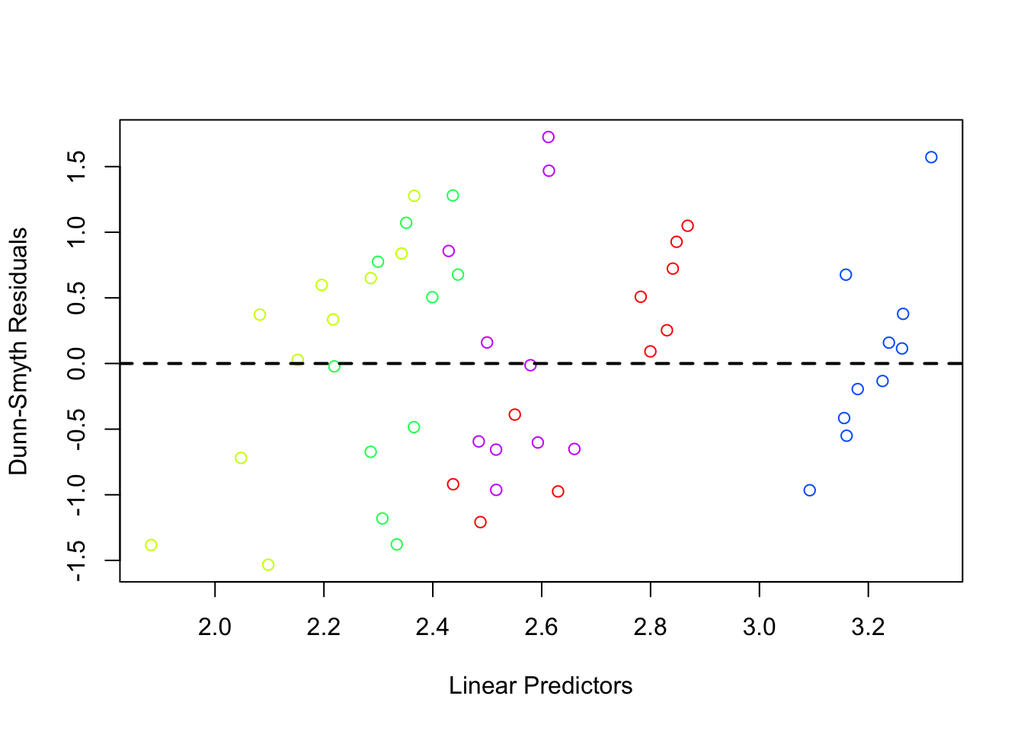

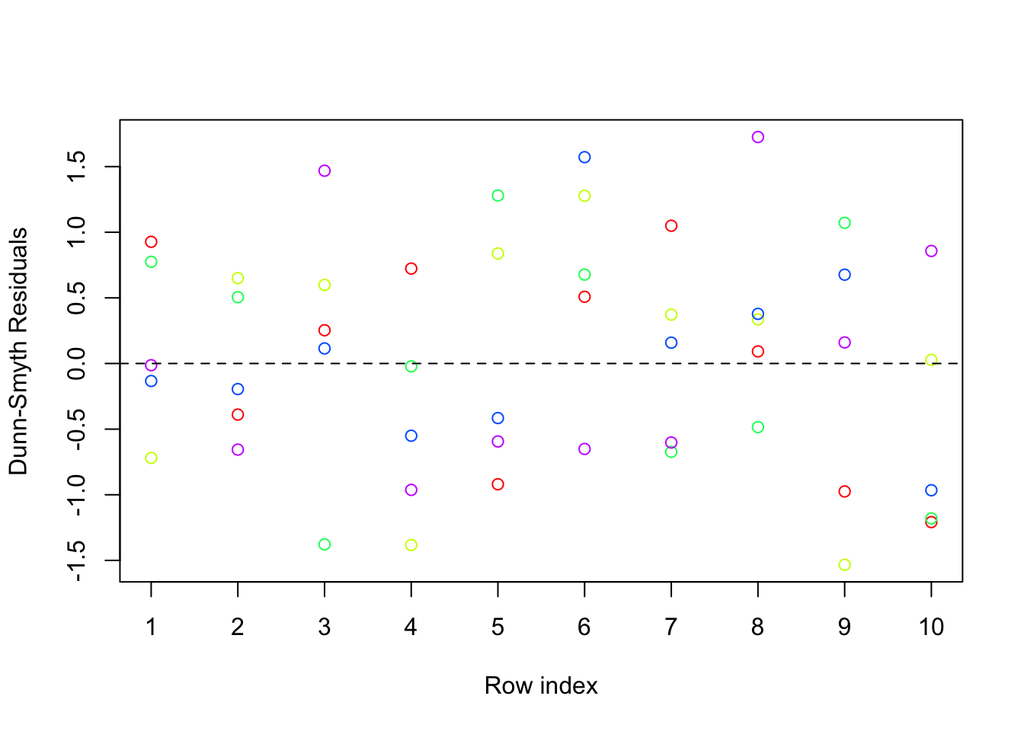

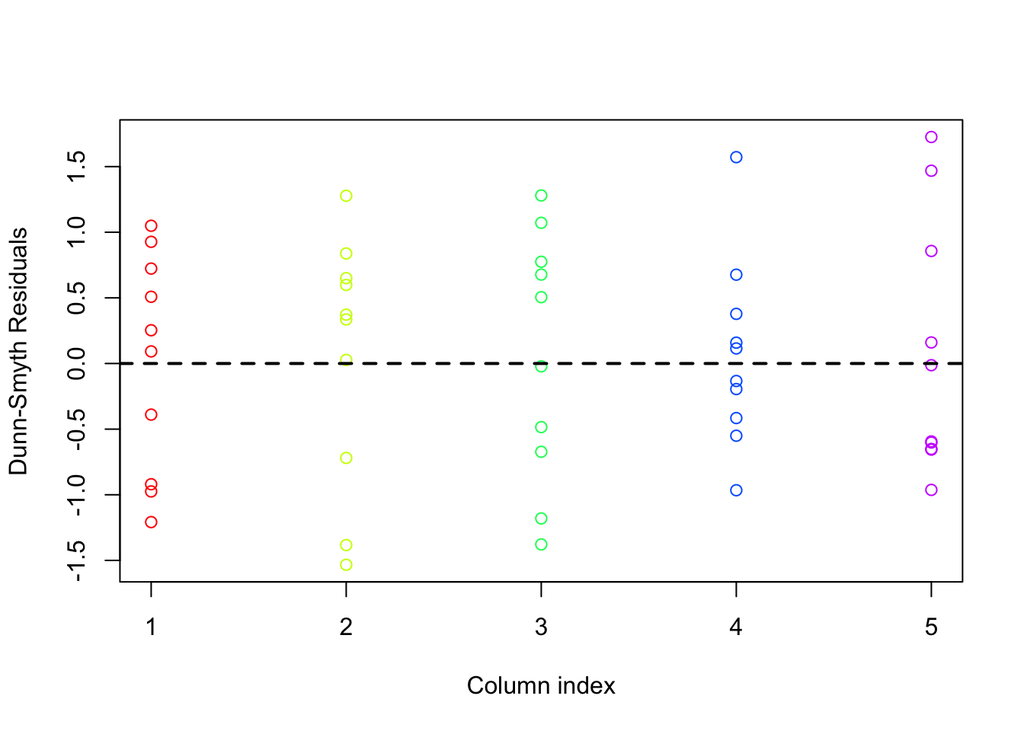

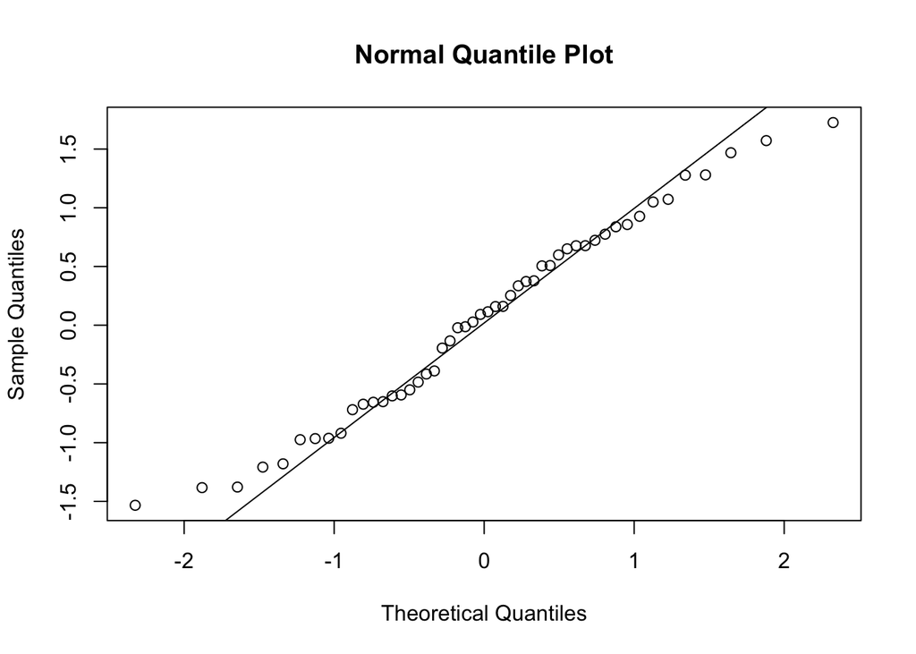

```r
## Dunn-Smyth residual plots  to check model assumption, outliers etc...
plot(fit.lvm)
```

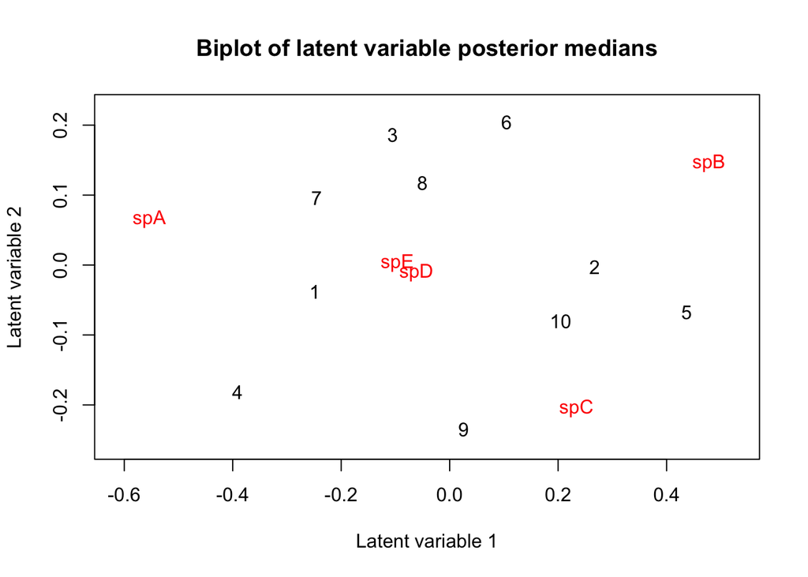

```r
## Please note that boral currently does not automatically produce biplots, although species loadings can be obtained from fit.lvm$lv.coefs.median[,2:3]
lvsplot(fit.lvm)
```

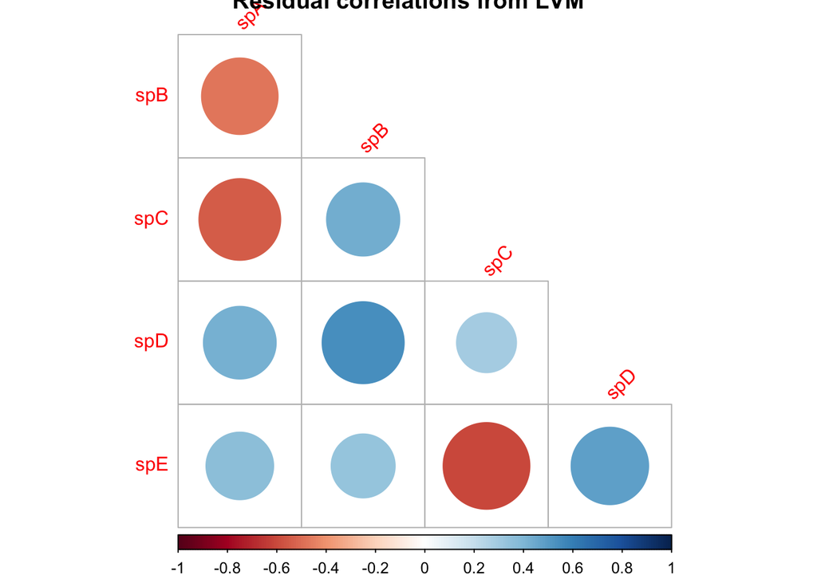

```r
## Use corrplot package to plot residual correlations between species, e.g. possibly due to species interaction etc...
res.cors <- get.residual.cor(fit.lvm)
corrplot::corrplot(res.cors$cor, diag = F, type = "lower", title = "Residual correlations from LVM", tl.srt = 45)
```

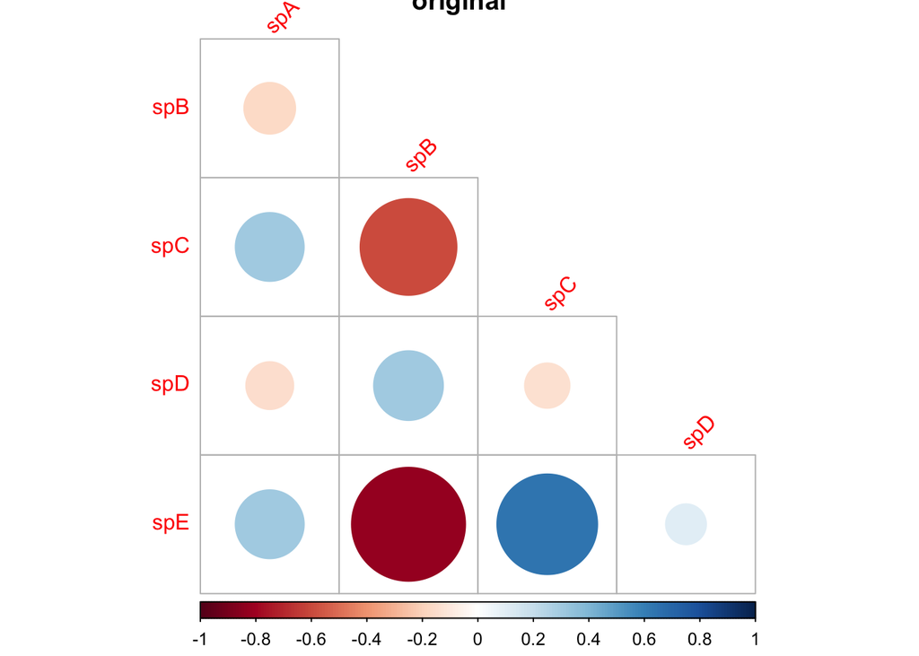

```r
corrplot::corrplot(sppcors, diag = F, type = "lower", title = "original", tl.srt = 45)
```

I… don’t get why these are not the same. In these data there *aren’t* anything but residual correlations! should these two figures resemble each other?

## via Stan

If I’m totally honest, my preference would be to write one of these models in Stan. Because I have several use cases in mind, but I might need more flexibility than boral provides right now. On the other hand, perhaps it is better not to get too “creative”..

Frankly, Stan is something that I have gotten used to using, and I would rather keep everything in the same tool if I possibly could!

## Taking the easy way – `rethinking`

I can’t tell, but shouldn’t it be possible to fit this with `rethinking`?

```r
simple_model <- alist(
  obs_abd   ~  dpois(lamb),
  log(lamb) <- inter +
    site_intercept[site_id] +
    spp_intercept[spp_id],
  inter                    ~ dnorm(0, 5),
  # distribution of sites
  site_intercept[site_id]  ~ dnorm(0, sitevar),
  sitevar                  ~ dcauchy(0, 4),
  # distribution of species
  spp_intercept[spp_id]    ~ dnorm(0, sppvar),
  sppvar                   ~ dcauchy(0, 4)
)
library(rstan)
test_model <- rethinking::map2stan(simple_model, species_sites)
# rethinking::stancode(test_model)
summary(test_model)
```

No, it is not, but `rethinking` does help by creating Stan code that I can then edit by hand.

```
data{
    int<lower=1> N;
    int<lower=1> N_site_id;
    int<lower=1> N_spp_id;
    int obs_abd[N];
    int spp_id[N];
    int site_id[N];
}
parameters{
    real inter;
    vector[N_site_id] site_intercept;
    real<lower=0> sitevar;
    vector[N_spp_id] spp_intercept;
    real<lower=0> sppvar;
    // adding this part: latent variables? is that you?
    matrix[N_site_id, 2] latent_vars;
    matrix[2, N_spp_id] spp_loadings;
}
model{
    vector[N] lamb;
    sppvar ~ cauchy( 0 , 4 );
    spp_intercept ~ normal( 0 , sppvar );
    sitevar ~ cauchy( 0 , 4 );
    site_intercept ~ normal( 0 , sitevar );
    inter ~ normal( 0 , 5 );
    // latent variable priors??
    for (j in 1:N_site_id){
      for(k in 1:2 ){
        latent_vars[j, k] ~ normal(0, 1);
      }
    }
    // and the species loadings?
    for (j in 1:N_spp_id){
      for(k in 1:2 ){
        spp_loadings[k, j] ~ normal(0, 3);
      }
    }
    // add the row of
    for ( i in 1:N ) {
        lamb[i] = inter + site_intercept[site_id[i]] + spp_intercept[spp_id[i]] + latent_vars[site_id[i],] * spp_loadings[,spp_id[i]];
    }
    obs_abd ~ poisson_log( lamb );
}
generated quantities{
    vector[N] lamb;
    real dev;
    dev = 0;
    for ( i in 1:N ) {
        lamb[i] = inter + site_intercept[site_id[i]] + spp_intercept[spp_id[i]];
    }
    dev = dev + (-2)*poisson_log_lpmf( obs_abd | lamb );
}
```

```r
# prepare data
knitr::kable(head(species_sites))
```

| site | spp | true_mean | obs_abd | spp_id | site_id |
| --- | --- | --- | --- | --- | --- |
| 1 | spA | 16.332633 | 21 | 1 | 1 |
| 1 | spB | 8.079800 | 6 | 2 | 1 |
| 1 | spC | 9.928633 | 12 | 3 | 1 |
| 1 | spD | 20.994232 | 24 | 4 | 1 |
| 1 | spE | 13.710633 | 13 | 5 | 1 |
| 10 | spA | 17.537230 | 11 | 1 | 2 |

```r
data_for_stan <- list(obs_abd  = species_sites$obs_abd,
                      site_id  = species_sites$site_id,
                      spp_id   = species_sites$spp_id,
                      N = nrow(species_sites),
                      N_site_id = length(unique(species_sites$site_id)),
                      N_spp_id = length(unique(species_sites$spp_id)))

results_lv_stan <- stan("lv_based_on_rethinking.stan", data = data_for_stan, chains = 2)
```

[output not shown]

[output cut: 8 more lines]

```
## Iteration:  200 / 2000 [ 10%]  (Warmup)
## Iteration:  400 / 2000 [ 20%]  (Warmup)
## Iteration:  600 / 2000 [ 30%]  (Warmup)
## Iteration:  800 / 2000 [ 40%]  (Warmup)
## Iteration: 1000 / 2000 [ 50%]  (Warmup)
## Iteration: 1001 / 2000 [ 50%]  (Sampling)
## Iteration: 1200 / 2000 [ 60%]  (Sampling)
## Iteration: 1400 / 2000 [ 70%]  (Sampling)
## Iteration: 1600 / 2000 [ 80%]  (Sampling)
## Iteration: 1800 / 2000 [ 90%]  (Sampling)
## Iteration: 2000 / 2000 [100%]  (Sampling)
##
##  Elapsed Time: 2.18456 seconds (Warm-up)
##                2.09139 seconds (Sampling)
##                4.27595 seconds (Total)
```

```r
list_of_draws <- rstan::extract(results_lv_stan)

str(list_of_draws$spp_loadings)
```

```
##  num [1:2000, 1:2, 1:5] 1.4963 -0.2968 1.6973 0.2762 -0.0295 ...
##  - attr(*, "dimnames")=List of 3
##   ..$ iterations: NULL
##   ..$           : NULL
##   ..$           : NULL
```

```r
median_loadings <- apply(list_of_draws$spp_loadings, c(2,3), median)
```

Now we have posterior draws from the $\Lambda$ matrix, which, apparently, if multiplied together would give an approximation of the covariance matrix..

```r
t(median_loadings) %*% median_loadings
```

```
##              [,1]         [,2]         [,3]         [,4]         [,5]
## [1,] 5.412859e-04 1.920973e-04 2.326281e-05 4.680848e-04 5.109228e-04
## [2,] 1.920973e-04 6.852234e-05 6.083751e-06 1.648891e-04 1.763544e-04
## [3,] 2.326281e-05 6.083751e-06 1.452526e-05 2.777524e-05 5.289069e-05
## [4,] 4.680848e-04 1.648891e-04 2.777524e-05 4.091194e-04 4.593426e-04
## [5,] 5.109228e-04 1.763544e-04 5.289069e-05 4.593426e-04 5.530062e-04
```

These numbers are the right shape (5 x 5) but their values are WAY too small! Evidentently I am missing a step here. I understand that `boral` applys some kind of “scale” to these values. Clearly I’m missing that here.

## Conclusions (?)

There’s not much success to report here. None of these approaches really nailed the experience of reproducing a covariance matrix.

### Obvious next steps

Exactly how bad are these approaches? They probably do better with more samples – how much better?  
Assuming that the approaches I’m taking here are actually valid, this could be the foundation for a power analysis of some kind.

While I can write something in Stan that runs, and seems to do what is required, I can’t manage to interpret the results in the same way as the boral output.

## References

Warton, David I, F Guillaume Blanchet, Robert B O’Hara, Otso Ovaskainen, Sara Taskinen, Steven C Walker, and Francis K C Hui. 2015. “So Many Variables: Joint Modeling in Community Ecology.” *Trends Ecol. Evol.* 30 (12): 766–79.